# Introduction to R Notebooks

## Architecture for Notebook Projects

For larger projects with multiple notebooks:

1. **Directory Structure**:

   ```
   project/
   ├── data/               # Raw data files
   ├── processed_data/     # Cleaned/transformed data
   ├── notebooks/          # R notebooks for analysis
   ├── R/                  # Reusable R functions
   ├── output/             # Generated figures and tables
   └── README.md           # Project documentation
   ```

## Keyboard Shortcuts

Useful keyboard shortcuts for R Notebooks: - Insert code chunk: Ctrl+Alt+I (Cmd+Option+I on Mac) - Run current chunk: Ctrl+Shift+Enter - Run current line: Ctrl+Enter - Run all chunks above: Alt+Ctrl+P - Run all chunks: Ctrl+Alt+R

## Interactive Example: Linear Regression

Let’s pull everything together with a complete analysis example:

```r
# Load data
data(mtcars)

# Explore relationship
plot(mtcars$wt, mtcars$mpg,
     main = "Car Weight vs. Fuel Efficiency",
     xlab = "Weight (1000 lbs)",
     ylab = "Miles Per Gallon",
     pch = 19, col = "darkblue")

# Fit linear model
model <- lm(mpg ~ wt, data = mtcars)

# Add regression line
abline(model, col = "red", lwd = 2)
```

```r
# Model summary
summary(model)
```

```
Call:
lm(formula = mpg ~ wt, data = mtcars)

Residuals:
    Min      1Q  Median      3Q     Max
-4.5432 -2.3647 -0.1252  1.4096  6.8727

Coefficients:
            Estimate Std. Error t value Pr(>|t|)
(Intercept)  37.2851     1.8776  19.858  < 2e-16 ***
wt           -5.3445     0.5591  -9.559 1.29e-10 ***
---
Signif. codes:  0 ‘***’ 0.001 ‘**’ 0.01 ‘*’ 0.05 ‘.’ 0.1 ‘ ’ 1

Residual standard error: 3.046 on 30 degrees of freedom
Multiple R-squared:  0.7528,    Adjusted R-squared:  0.7446
F-statistic: 91.38 on 1 and 30 DF,  p-value: 1.294e-10
```

```r
# Diagnostic plots
par(mfrow = c(2, 2))
```

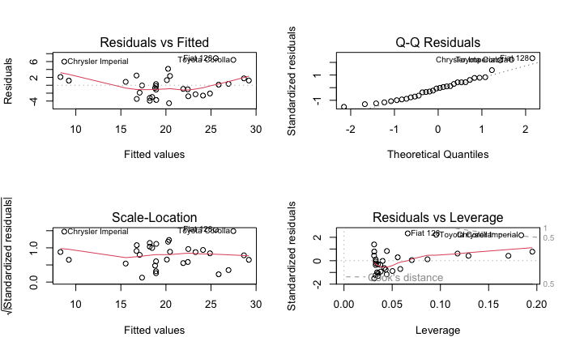

```r
plot(model)
par(mfrow = c(1, 1))
```

## Additional Best Practices

### Managing Verbose Output

For operations that generate verbose output (like data cleaning):

```r
# This code will run but won't display messages, warnings, or results
library(dplyr)
large_dataset <- read.csv("large_file.csv") %>%
  filter(!is.na(important_column)) %>%
  mutate(new_var = complicated_calculation(old_var))
```

### Documentation vs. Analysis Notebooks

Consider creating different types of notebooks:

1. **Processing notebooks**: Focus on data cleaning and preparation
   - More code-heavy
   - Include detailed comments
   - Often run once to generate clean data
2. **Analysis notebooks**: Focus on insights and visualization
   - More narrative-focused
   - Include interpretations of results
   - Designed for sharing with stakeholders
3. **Report notebooks**: Polished presentation of findings
   - Minimal visible code (`echo=FALSE` for most chunks)
   - Emphasis on visualizations and conclusions
   - Formatted for non-technical audiences

### Interactive Elements

For complex projects, consider adding interactive elements:

```r
# Adding interactive widgets
library(shiny)
library(plotly)

# Create interactive plot
p <- ggplotly(ggplot(mtcars, aes(x = wt, y = mpg)) + geom_point())
p
```

## Conclusion

R Notebooks provide a powerful way to combine code, output, and narrative in a single document. They’re perfect for: - Data analysis reports - Teaching materials - Research papers - Sharing reproducible work

With proper organization and best practices, R Notebooks can streamline your workflow from data cleaning to publication-ready reports, while maintaining reproducibility throughout the process.

Now you’re ready to create your own R Notebooks!